# Diversity project actual analyses I swear

```r
ggsave("fig4_disease_by_descriptor_slim.pdf", width = 7, height = 4.5)
ggsave("fig4_disease_by_descriptor_slim.png", width = 7, height = 4.5)

# Some statistics: The percentage of samples that each tissue accounts for, and how many descriptors are associated:
options(scipen = 20)

allSRAFinal %>% drop_na(finalDisease) %>% count(finalDisease) %>% summarise(finalDisease = finalDisease, n = n, proportion = n/sum(n)) %>% as.data.frame
```

```
##         finalDisease    n  proportion
## 1       Acute trauma   12 0.001958864
## 2         Autoimmune  983 0.160463598
## 3              Blood   25 0.004080966
## 4             Cancer 1522 0.248449233
## 5     Cardiovascular   57 0.009304603
## 6          Endocrine   10 0.001632387
## 7   Gastrointestinal    7 0.001142671
## 8   Genetic syndrome   57 0.009304603
## 9    Healthy control 2050 0.334639243
## 10        Infectious  330 0.053868756
## 11     Integumentary    7 0.001142671
## 12            Kidney   17 0.002775057
## 13     Mental health  465 0.075905975
## 14         Metabolic  234 0.038197845
## 15 Neurodegenerative  183 0.029872674
## 16      Neurological   14 0.002285341
## 17             Other    9 0.001469148
## 18      Reproductive   17 0.002775057
## 19       Respiratory  127 0.020731309
```

```r
allSRAFinal %>% count(hasDescriptor, finalDisease) %>% group_by(hasDescriptor) %>% summarise(finalDisease = finalDisease, n = n, proportion = n/sum(n)) %>% as.data.frame
```

```
##    hasDescriptor      finalDisease     n    proportion
## 1     Geographic      Acute trauma    12 0.00122411507
## 2     Geographic        Autoimmune   674 0.06875446292
## 3     Geographic             Blood    24 0.00244823013
## 4     Geographic            Cancer   548 0.05590125472
## 5     Geographic    Cardiovascular    44 0.00448842191
## 6     Geographic         Endocrine    10 0.00102009589
## 7     Geographic  Gastrointestinal     7 0.00071406712
## 8     Geographic  Genetic syndrome    57 0.00581454657
## 9     Geographic   Healthy control  1133 0.11557686423
## 10    Geographic        Infectious   276 0.02815464654
## 11    Geographic     Integumentary     7 0.00071406712
## 12    Geographic            Kidney    17 0.00173416301
## 13    Geographic     Mental health    28 0.00285626849
## 14    Geographic         Metabolic     7 0.00071406712
```

[output cut: 20 more lines]

```r
allSRAFinal %>% count(worldRegion, finalDisease) %>% group_by(worldRegion) %>% summarise(finalDisease = finalDisease, n = n, proportion = n/sum(n)) %>% arrange(finalDisease) %>% as.data.frame
```

```
##                    worldRegion      finalDisease     n    proportion
## 1         East Asia &\nPacific      Acute trauma    12 0.00667408231
## 2         East Asia &\nPacific        Autoimmune    98 0.05450500556
## 3       Europe &\nCentral Asia        Autoimmune    32 0.00538176926
## 4   Latin America &\nCaribbean        Autoimmune     1 0.01190476190
## 5                North America        Autoimmune   852 0.05356469257
## 6         East Asia &\nPacific             Blood    23 0.01279199110
## 7   Latin America &\nCaribbean             Blood     1 0.01190476190
## 8                North America             Blood     1 0.00006286936
## 9         East Asia &\nPacific            Cancer   380 0.21134593993
## 10      Europe &\nCentral Asia            Cancer   205 0.03447695930
## 11  Latin America &\nCaribbean            Cancer    23 0.27380952381
## 12               North America            Cancer   900 0.05658242173
## 13                        <NA>            Cancer    14 0.43750000000
## 14        East Asia &\nPacific    Cardiovascular    27 0.01501668521
```

[output cut: 41 more lines]

```r
allSRAFinal %>% count(worldRegion, finalDisease) %>% group_by(finalDisease) %>% summarise(worldRegion = worldRegion, n = n, proportion = n/sum(n)) %>% arrange(finalDisease) %>% as.data.frame
```

```
##         finalDisease                 worldRegion     n   proportion
## 1       Acute trauma        East Asia &\nPacific    12 1.0000000000
## 2         Autoimmune        East Asia &\nPacific    98 0.0996948118
## 3         Autoimmune      Europe &\nCentral Asia    32 0.0325534079
## 4         Autoimmune  Latin America &\nCaribbean     1 0.0010172940
## 5         Autoimmune               North America   852 0.8667344863
## 6              Blood        East Asia &\nPacific    23 0.9200000000
## 7              Blood  Latin America &\nCaribbean     1 0.0400000000
## 8              Blood               North America     1 0.0400000000
## 9             Cancer        East Asia &\nPacific   380 0.2496714849
## 10            Cancer      Europe &\nCentral Asia   205 0.1346911958
## 11            Cancer  Latin America &\nCaribbean    23 0.0151116951
## 12            Cancer               North America   900 0.5913272011
## 13            Cancer                        <NA>    14 0.0091984231
## 14    Cardiovascular        East Asia &\nPacific    27 0.4736842105
```

[output cut: 41 more lines]

```r
allSRAFinal %>% count(finalDisease, strictestGeography) %>% drop_na(strictestGeography) %>% group_by(finalDisease) %>% summarise(geoGroups = length(finalDisease)) %>% arrange(desc(geoGroups)) %>% as.data.frame
```

```
##         finalDisease geoGroups
## 1               <NA>        11
## 2    Healthy control         8
## 3         Autoimmune         7
## 4             Cancer         5
## 5         Infectious         5
## 6        Respiratory         4
## 7     Cardiovascular         3
## 8  Neurodegenerative         3
## 9       Acute trauma         2
## 10             Blood         2
## 11  Gastrointestinal         2
## 12     Mental health         2
## 13         Metabolic         2
## 14         Endocrine         1
## 15  Genetic syndrome         1
## 16     Integumentary         1
## 17            Kidney         1
## 18      Neurological         1
## 19             Other         1
## 20      Reproductive         1
```

```r
allSRAFinal %>% count(finalDisease, strictestRace) %>% drop_na(strictestRace) %>% group_by(finalDisease) %>% summarise(raceGroups = length(finalDisease)) %>% arrange(desc(raceGroups)) %>% as.data.frame
```

```
##         finalDisease raceGroups
## 1               <NA>          8
## 2             Cancer          7
## 3         Autoimmune          6
## 4    Healthy control          6
## 5          Metabolic          4
## 6         Infectious          3
## 7      Mental health          3
## 8       Neurological          3
## 9  Neurodegenerative          2
## 10             Blood          1
## 11    Cardiovascular          1
## 12             Other          1
## 13      Reproductive          1
## 14       Respiratory          1
```

```r
# And how many tissues is each descriptor associated with?
allSRAFinal %>% drop_na(strictestGeography, finalDisease) %>% count(finalDisease)
```

```
##         finalDisease    n
## 1       Acute trauma   12
## 2         Autoimmune  674
## 3              Blood   24
## 4             Cancer  548
## 5     Cardiovascular   44
## 6          Endocrine   10
## 7   Gastrointestinal    7
## 8   Genetic syndrome   57
## 9    Healthy control 1133
## 10        Infectious  276
## 11     Integumentary    7
## 12            Kidney   17
## 13     Mental health   28
## 14         Metabolic    7
## 15 Neurodegenerative   72
## 16      Neurological    6
## 17             Other    7
## 18      Reproductive   10
## 19       Respiratory  107
```

```r
allSRAFinal %>% drop_na(strictestRace, finalDisease) %>% count(finalDisease)
```

```
##         finalDisease   n
## 1         Autoimmune 309
## 2              Blood   1
## 3             Cancer 974
## 4     Cardiovascular  13
## 5    Healthy control 917
## 6         Infectious  54
## 7      Mental health 437
## 8          Metabolic 227
## 9  Neurodegenerative 111
## 10      Neurological   8
## 11             Other   2
## 12      Reproductive   7
## 13       Respiratory  20
```

```r
allSRAFinal %>% count(finalDisease, strictestGeography) %>% drop_na(strictestGeography) %>% group_by(strictestGeography) %>% summarise(geoGroups = length(strictestGeography)) %>% arrange(desc(geoGroups)) %>% as.data.frame
```

```
##                strictestGeography geoGroups
## 1                          Europe        13
## 2                       East Asia        11
## 3              Sub-Saharan Africa         8
## 4                        Americas         7
## 5                      South Asia         6
## 6                      Asia (NOS)         5
## 7                        Multiple         4
## 8                           Other         4
## 9  North Africa and\nWestern Asia         3
## 10                 Southeast Asia         1
## 11                        Oceania         1
```

```r
allSRAFinal %>% count(finalDisease, strictestRace) %>% drop_na(strictestRace) %>% group_by(strictestRace) %>% summarise(raceGroups = length(strictestRace)) %>% arrange(desc(raceGroups)) %>% as.data.frame
```

```
##                                 strictestRace raceGroups
## 1                                    Hispanic         10
## 2                                       White         10
## 3                  Black or\nAfrican American          9
## 4                                       Asian          7
## 5                                       Other          4
## 6                                    Multiple          3
## 7          American Indian and\nAlaska Native          2
## 8 Native Hawaiian and\nother Pacific Islander          2
```

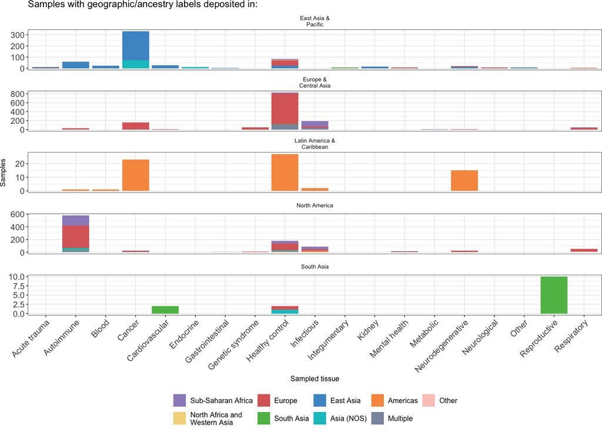

```r
# And now some alluvial plots, for funsies and supplementary data:
geoDiseaseFacet <- geographySummary %>% group_by(finalDisease, strictestGeography, worldRegion) %>% summarise(value = sum(n)) %>% distinct() %>% drop_na(c(finalDisease, strictestGeography, worldRegion)) %>% as.data.frame %>%
  ggplot(., aes(x = finalDisease, y = value, fill = strictestGeography)) +
  geom_bar(stat="identity") +
  ggtitle("Samples with geographic/ancestry labels deposited in:") +
  xlab("Sampled tissue") +
  ylab("Samples") +
  scale_fill_geography(name="Population\nDescriptor") +
  guides(fill=guide_legend(title="", nrow=2)) +
  theme(axis.text.x = element_text(angle = 45, hjust=1, vjust=1)) +
  theme(legend.title = element_blank(), legend.position="bottom", legend.direction="horizontal") +
  theme(strip.background = element_blank()) +
  facet_wrap(~worldRegion, ncol=1, scales="free_y")
geoDiseaseFacet
```

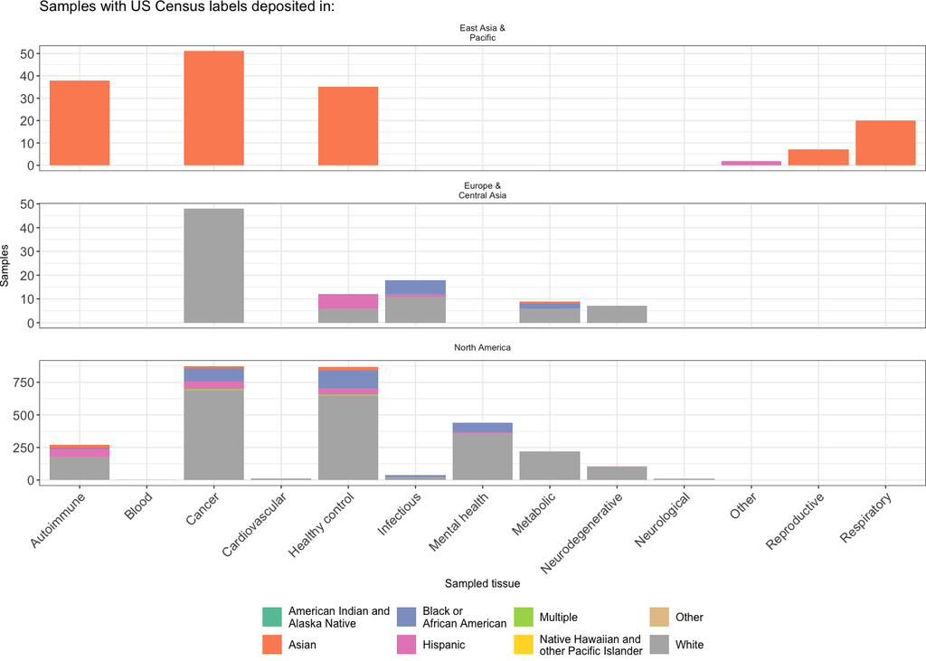

```r
ggsave("fig4_disease_by_geography_faceted.pdf", width=6, height=9)
ggsave("fig4_disease_by_geography_faceted.png", width=6, height=9)

raceDiseaseFacet <- raceSummary %>% group_by(finalDisease, strictestRace, worldRegion) %>% summarise(value = sum(n)) %>% distinct() %>% drop_na(c(finalDisease, strictestRace, worldRegion)) %>% as.data.frame %>%
  ggplot(., aes(x = finalDisease, y = value, fill = strictestRace)) +
  geom_bar(stat="identity") +
  ggtitle("Samples with US Census labels deposited in:") +
  xlab("Sampled tissue") +
  ylab("Samples") +
  scale_fill_race(name="US Census\nTerm)") +
  guides(fill=guide_legend(title="")) +
  theme(axis.text.x = element_text(angle = 45, hjust=1, vjust=1)) +
  theme(legend.title = element_blank(), legend.position="bottom", legend.direction="horizontal") +
  theme(strip.background = element_blank()) +
  facet_wrap(~worldRegion, ncol=1, scales="free_y")
raceDiseaseFacet
```

```r
ggsave("fig4_disease_by_race_faceted.pdf", width=6, height=9)
ggsave("fig4_disease_by_race_faceted.png", width=6, height=9)
```

### A new figure 4 that combines figures 3 and 4

Here we are simply playing with plots, no new analyses being done at all, but we remove legends from the previous figure 4 panels, because they’re not needed. Miraculously it all fits.

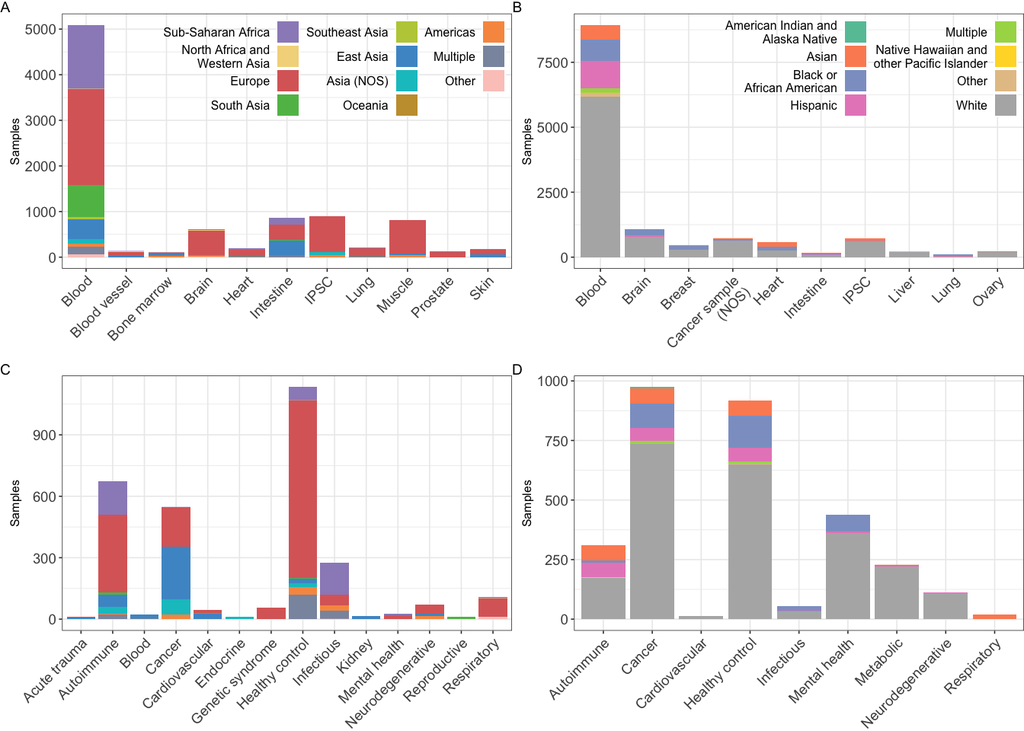

```r
geoDiseaseSlim2 <- geoDiseaseSlim +
    theme(legend.position="none")

raceDiseaseSlim2 <- raceDiseaseSlim +
    theme(legend.position="none")

geoOrganSlim + raceOrganSlim + geoDiseaseSlim2 + raceDiseaseSlim2 +
  plot_layout(design=twox2DesignRowWise) +
  plot_annotation(tag_levels = 'A')
```

```r
ggsave("fig4_tissue_disease_combined_plots.pdf", width=6, height=6)
ggsave("fig4_tissue_disease_combined_plots.png", width=6, height=6)
```

## 4. Attempting to look at some of the relationships between classes:

What we really want to get to is the relationship between tissue and disease, because we think it might be interesting.

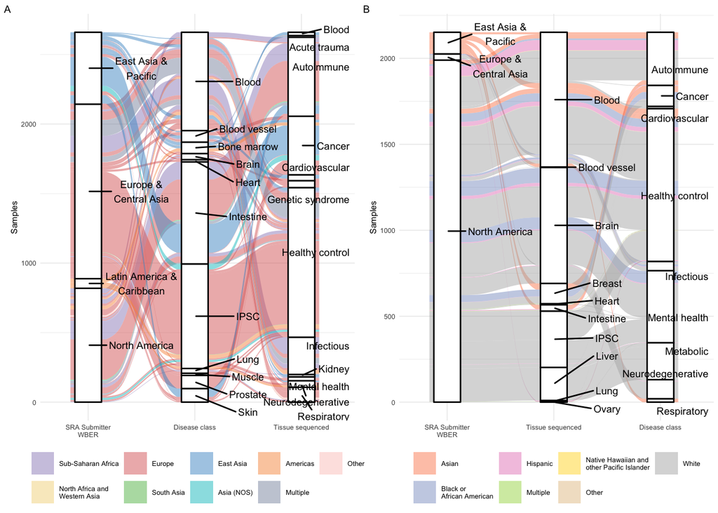

```r
# Let's collapse tissues with under 100 observations and diseases with under 10 into "Other"
geoTissuesToKeep <- allSRAFinal %>% drop_na(strictestGeography) %>% count(finalOrgan) %>% filter(n >= 100)
raceTissuesToKeep <- allSRAFinal %>% drop_na(strictestRace) %>% count(finalOrgan) %>% filter(n >= 100)

geoDiseasesToKeep <- allSRAFinal %>% drop_na(strictestGeography) %>% count(finalDisease) %>% filter(n >= 10)
raceDiseasesToKeep <- allSRAFinal %>% drop_na(strictestRace) %>% count(finalDisease) %>% filter(n >= 10)

geoDisAlluvial <- allSRAFinal %>% drop_na(c(strictestGeography, worldRegion, finalOrgan, finalDisease)) %>% count(worldRegion, strictestGeography, finalOrgan, finalDisease) %>%
filter(grepl(paste(geoTissuesToKeep$finalOrgan, collapse="|"), finalOrgan)) %>%
filter(grepl(paste(geoDiseasesToKeep$finalDisease, collapse="|"), finalDisease)) %>%
    ggplot(data = .,
       aes(axis1 = worldRegion, axis2 = finalOrgan, axis3 = finalDisease, y = n)) +
  scale_x_discrete(limits = c("SRA Submitter\nWBER", "Disease class", "Tissue sequenced"), expand = c(.2, .05)) +
  geom_alluvium(aes(fill = strictestGeography)) +
  scale_fill_geography() +
  geom_stratum(width=1/4) +
  ylab("Samples") +
  # geom_text(stat = "stratum", aes(label = after_stat(stratum)), size=2.5) +
  geom_text_repel(stat = "stratum", aes(label = after_stat(stratum)), size = 2.5, direction = "y", nudge_x = .5) +
  theme_minimal(base_size = 6) +
  guides(fill=guide_legend(title="Descriptor", nrow=2)) +
  theme(legend.title = element_blank(), legend.position="bottom", legend.direction="horizontal")

raceDisAlluvial <- allSRAFinal %>% drop_na(c(strictestRace, worldRegion, finalOrgan, finalDisease)) %>% count(worldRegion, strictestRace, finalOrgan, finalDisease) %>%
  filter(grepl(paste(raceTissuesToKeep$finalOrgan, collapse="|"), finalOrgan)) %>%
  filter(grepl(paste(raceDiseasesToKeep$finalDisease, collapse="|"), finalDisease)) %>%
ggplot(data = .,
       aes(axis1 = worldRegion, axis2 = finalOrgan, axis3 = finalDisease, y = n)) +
  scale_x_discrete(limits = c("SRA Submitter\nWBER", "Tissue sequenced", "Disease class"), expand = c(.2, .05)) +
  geom_alluvium(aes(fill = strictestRace)) +
  scale_fill_race() +
  geom_stratum(width=1/4) +
  ylab("Samples") +
  # geom_text(stat = "stratum", aes(label = after_stat(stratum)), size=2.5) +
  geom_text_repel(stat = "stratum", aes(label = after_stat(stratum)), size = 2.5, direction = "y", nudge_x = .5) +
  theme_minimal(base_size = 6) +
  guides(fill=guide_legend(title="Descriptor", nrow=2)) +
  theme(legend.title = element_blank(), legend.position="bottom", legend.direction="horizontal")

geoDisAlluvial + raceDisAlluvial +
  plot_layout(design=long2Design) +
  plot_annotation(tag_levels = 'A')
```

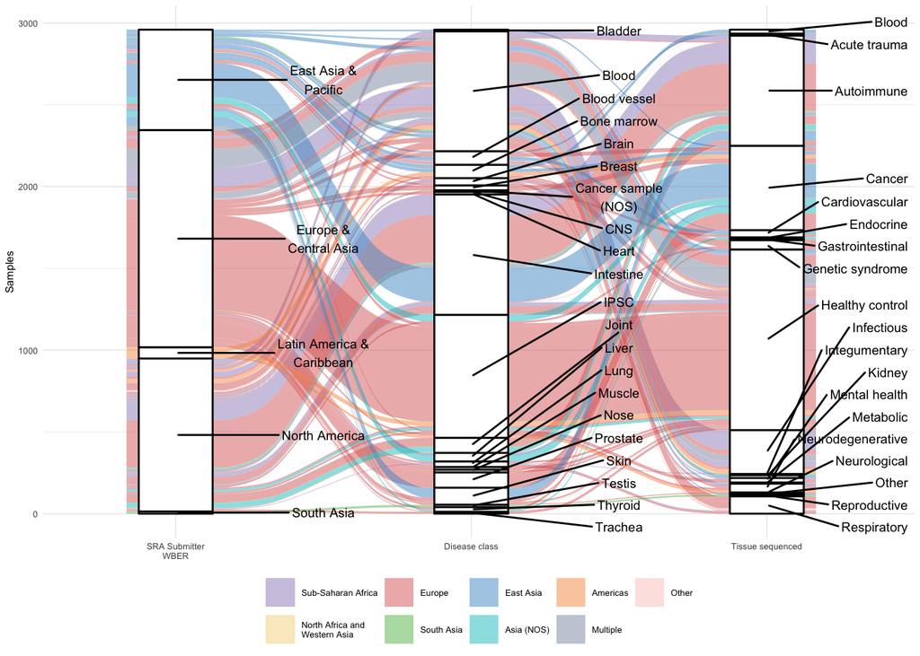

```r
ggsave("fig4_organ_disease_alluvial.pdf", width = 7, height = 7)
geoDisAlluvial <- allSRAFinal %>% drop_na(c(strictestGeography, worldRegion, finalOrgan, finalDisease)) %>% count(worldRegion, strictestGeography, finalOrgan, finalDisease) %>%
    ggplot(data = .,
       aes(axis1 = worldRegion, axis2 = finalOrgan, axis3 = finalDisease, y = n)) +
  scale_x_discrete(limits = c("SRA Submitter\nWBER", "Disease class", "Tissue sequenced"), expand = c(.2, .05)) +
  geom_alluvium(aes(fill = strictestGeography)) +
  scale_fill_geography() +
  geom_stratum(width=1/4) +
  ylab("Samples") +
  # geom_text(stat = "stratum", aes(label = after_stat(stratum)), size=2.5) +
  geom_text_repel(stat = "stratum", aes(label = after_stat(stratum)), size = 2.5, direction = "y", nudge_x = .5) +
  theme_minimal(base_size = 6) +
  guides(fill=guide_legend(title="Descriptor", nrow=2)) +
  theme(legend.title = element_blank(), legend.position="bottom", legend.direction="horizontal")

geoDisAlluvial
```

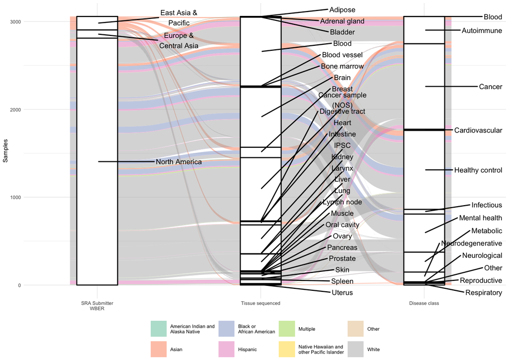

```r
ggsave("fig4_organ_disease_geo_alluvial_full.pdf", width = 7, height = 7)
ggsave("fig4_organ_disease_geo_alluvial_full.png", width = 7, height = 7)
raceDisAlluvial <- allSRAFinal %>% drop_na(c(strictestRace, worldRegion, finalOrgan, finalDisease)) %>% count(worldRegion, strictestRace, finalOrgan, finalDisease) %>%
ggplot(data = .,
       aes(axis1 = worldRegion, axis2 = finalOrgan, axis3 = finalDisease, y = n)) +
  scale_x_discrete(limits = c("SRA Submitter\nWBER", "Tissue sequenced", "Disease class"), expand = c(.2, .05)) +
  geom_alluvium(aes(fill = strictestRace)) +
  scale_fill_race() +
  geom_stratum(width=1/4) +
  ylab("Samples") +
  # geom_text(stat = "stratum", aes(label = after_stat(stratum)), size=2.5) +
  geom_text_repel(stat = "stratum", aes(label = after_stat(stratum)), size = 2.5, direction = "y", nudge_x = .5) +
  theme_minimal(base_size = 6) +
  guides(fill=guide_legend(title="Descriptor", nrow=2)) +
  theme(legend.title = element_blank(), legend.position="bottom", legend.direction="horizontal")

raceDisAlluvial
```

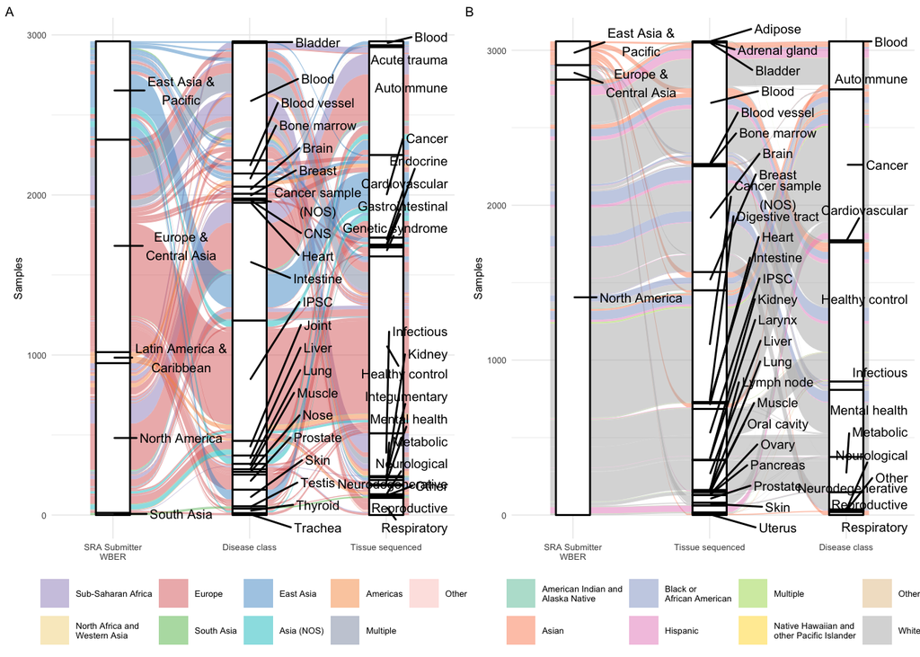

```r
ggsave("fig4_organ_disease_race_alluvial_full.pdf", width = 7, height = 7)
ggsave("fig4_organ_disease_race_alluvial_full.png", width = 7, height = 7)
geoDisAlluvial + raceDisAlluvial +
  plot_layout(design=long2Design) +
  plot_annotation(tag_levels = 'A')
```

```r
ggsave("fig4_organ_disease_alluvial_full.pdf", width = 7, height = 7)
```

And finally… the numbers that underlie these plots, because otherwise I’ll go crazy trying to tabulate things:

```r
allSRAFinal <- allSRAFinal %>%
  mutate(hasDisease = if_else(is.na(finalDisease), "No", "Yes"))

# Who has disease info?
allSRAFinal %>% count(hasDisease) %>% mutate(freq = n/sum(n))
```

```
##   hasDisease     n      freq
## 1         No 17677 0.7426375
## 2        Yes  6126 0.2573625
```

```r
allSRAFinal %>% drop_na(strictestGeography) %>% count(hasDisease) %>% mutate(freq = n/sum(n))
```

```
##   hasDisease    n      freq
## 1         No 6757 0.6892788
## 2        Yes 3046 0.3107212
```

```r
allSRAFinal %>% drop_na(strictestRace) %>% count(hasDisease) %>% mutate(freq = n/sum(n))
```

```
##   hasDisease     n freq
## 1         No 10920 0.78
## 2        Yes  3080 0.22
```

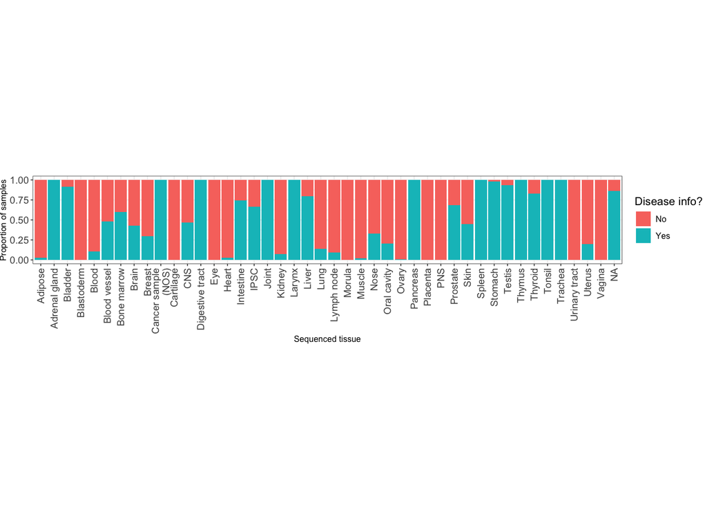

```r
# Some of these could work better as plots:
ggplot(allSRAFinal, aes(x = finalOrgan, fill = hasDisease)) +
  geom_bar(position = "fill") +
  ggtitle("") +
  xlab("Sequenced tissue") +
  ylab("Proportion of samples") +
  coord_fixed(ratio=6) +
  guides(fill=guide_legend(title="Disease info?")) +
  theme(axis.text.x = element_text(angle = 90, hjust=1, vjust=0.5))
```

```r
allSRAFinal %>% drop_na(finalOrgan) %>% count(hasDisease) %>% mutate(freq = n/sum(n))
```

```
##   hasDisease     n      freq
## 1         No 17665 0.7448872
## 2        Yes  6050 0.2551128
```

```r
allSRAFinal %>% drop_na(finalOrgan) %>% count(finalOrgan, hasDisease) %>% group_by(finalOrgan) %>% mutate(freq = n/sum(n)) %>% ungroup() %>% as.data.frame()
```

```
##              finalOrgan hasDisease     n        freq
## 1               Adipose         No   104 0.971962617
## 2               Adipose        Yes     3 0.028037383
## 3         Adrenal gland        Yes     3 1.000000000
## 4               Bladder         No     1 0.083333333
## 5               Bladder        Yes    11 0.916666667
## 6            Blastoderm         No    22 1.000000000
## 7                 Blood         No 12498 0.891695205
## 8                 Blood        Yes  1518 0.108304795
## 9          Blood vessel         No    94 0.519337017
## 10         Blood vessel        Yes    87 0.480662983
## 11          Bone marrow         No    62 0.402597403
## 12          Bone marrow        Yes    92 0.597402597
## 13                Brain         No   969 0.571344340
## 14                Brain        Yes   727 0.428655660
```

[output cut: 54 more lines]

```r
# Increasing levels of disease and geography granularity:
allSRAFinal %>% drop_na(strictestGeography) %>% count(strictestGeography, hasDisease) %>% mutate(freq = n/sum(n))
```

```
##                strictestGeography hasDisease    n         freq
## 1              Sub-Saharan Africa         No 1281 0.1306742834
## 2              Sub-Saharan Africa        Yes  406 0.0414158931
## 3  North Africa and\nWestern Asia         No   15 0.0015301438
## 4  North Africa and\nWestern Asia        Yes    3 0.0003060288
## 5                          Europe         No 3721 0.3795776803
## 6                          Europe        Yes 1730 0.1764765888
## 7                      South Asia         No  688 0.0701825972
## 8                      South Asia        Yes   30 0.0030602877
## 9                  Southeast Asia         No   49 0.0049984699
## 10                      East Asia         No  676 0.0689584821
## 11                      East Asia        Yes  438 0.0446801999
## 12                     Asia (NOS)         No  169 0.0172396205
## 13                     Asia (NOS)        Yes  137 0.0139753137
## 14                        Oceania         No   11 0.0011221055
## 15                       Americas         No   70 0.0071406712
## 16                       Americas        Yes  110 0.0112210548
## 17                       Multiple         No   27 0.0027542589
## 18                       Multiple        Yes  180 0.0183617260
## 19                          Other         No   50 0.0051004794
## 20                          Other        Yes   12 0.0012241151
```

```r
allSRAFinal %>% drop_na(strictestRace) %>% count(strictestRace, hasDisease) %>% mutate(freq = n/sum(n))
```

```
##                                  strictestRace hasDisease    n          freq
## 1           American Indian and\nAlaska Native         No   40 0.00285714286
## 2           American Indian and\nAlaska Native        Yes    5 0.00035714286
## 3                                        Asian         No  718 0.05128571429
## 4                                        Asian        Yes  218 0.01557142857
## 5                   Black or\nAfrican American         No 1392 0.09942857143
## 6                   Black or\nAfrican American        Yes  340 0.02428571429
## 7                                     Hispanic         No 1056 0.07542857143
## 8                                     Hispanic        Yes  191 0.01364285714
## 9                                     Multiple         No  182 0.01300000000
## 10                                    Multiple        Yes   21 0.00150000000
## 11 Native Hawaiian and\nother Pacific Islander         No    5 0.00035714286
## 12 Native Hawaiian and\nother Pacific Islander        Yes    1 0.00007142857
## 13                                       Other         No  158 0.01128571429
## 14                                       Other        Yes    4 0.00028571429
## 15                                       White         No 7369 0.52635714286
## 16                                       White        Yes 2300 0.16428571429
```

```r
allSRAFinal %>% drop_na(worldRegion) %>% count(worldRegion, hasDisease) %>% mutate(freq = n/sum(n))
```

```
##                    worldRegion hasDisease     n         freq
## 1         East Asia &\nPacific         No  1027 0.0432039039
## 2         East Asia &\nPacific        Yes   771 0.0324344790
## 3       Europe &\nCentral Asia         No  4524 0.1903159312
## 4       Europe &\nCentral Asia        Yes  1422 0.0598207900
## 5   Latin America &\nCaribbean         No    15 0.0006310210
## 6   Latin America &\nCaribbean        Yes    69 0.0029026966
## 7  Middle East &\nNorth Africa         No    11 0.0004627487
## 8                North America         No 12088 0.5085187834
## 9                North America        Yes  3818 0.1606158765
## 10                  South Asia         No    12 0.0005048168
## 11                  South Asia        Yes    14 0.0005889529
```

```r
allSRAFinal %>% drop_na(strictestGeography, finalDisease) %>% count(strictestGeography, finalDisease) %>% mutate(freq = n/sum(n))
```

```
##                strictestGeography      finalDisease   n         freq
## 1              Sub-Saharan Africa        Autoimmune 164 0.0538411031
## 2              Sub-Saharan Africa            Cancer   1 0.0003282994
## 3              Sub-Saharan Africa   Healthy control  66 0.0216677610
## 4              Sub-Saharan Africa        Infectious 155 0.0508864084
## 5              Sub-Saharan Africa     Mental health   8 0.0026263953
## 6              Sub-Saharan Africa         Metabolic   6 0.0019697965
## 7              Sub-Saharan Africa       Respiratory   6 0.0019697965
## 8  North Africa and\nWestern Asia   Healthy control   1 0.0003282994
## 9  North Africa and\nWestern Asia       Respiratory   2 0.0006565988
## 10                         Europe      Acute trauma   4 0.0013131976
## 11                         Europe        Autoimmune 380 0.1247537754
## 12                         Europe            Cancer 193 0.0633617859
## 13                         Europe    Cardiovascular  15 0.0049244911
## 14                         Europe  Gastrointestinal   2 0.0006565988
```

[output cut: 38 more lines]

```r
allSRAFinal %>% drop_na(strictestRace, finalDisease) %>% count(strictestRace, finalDisease) %>% mutate(freq = n/sum(n))
```

```
##                                  strictestRace      finalDisease   n         freq
## 1           American Indian and\nAlaska Native            Cancer   5 0.0016233766
## 2                                        Asian        Autoimmune  62 0.0201298701
## 3                                        Asian            Cancer  65 0.0211038961
## 4                                        Asian   Healthy control  63 0.0204545455
## 5                                        Asian         Metabolic   1 0.0003246753
## 6                                        Asian      Reproductive   7 0.0022727273
## 7                                        Asian       Respiratory  20 0.0064935065
## 8                   Black or\nAfrican American        Autoimmune  10 0.0032467532
## 9                   Black or\nAfrican American             Blood   1 0.0003246753
## 10                  Black or\nAfrican American            Cancer 100 0.0324675325
## 11                  Black or\nAfrican American   Healthy control 136 0.0441558442
## 12                  Black or\nAfrican American        Infectious  18 0.0058441558
## 13                  Black or\nAfrican American     Mental health  70 0.0227272727
## 14                  Black or\nAfrican American         Metabolic   2 0.0006493506
```

[output cut: 25 more lines]

```r
allSRAFinal %>% drop_na(worldRegion, finalDisease) %>% count(worldRegion, finalDisease) %>% mutate(freq = n/sum(n))
```

```
##                   worldRegion      finalDisease    n         freq
## 1        East Asia &\nPacific      Acute trauma   12 0.0019691500
## 2        East Asia &\nPacific        Autoimmune   98 0.0160813915
## 3        East Asia &\nPacific             Blood   23 0.0037742041
## 4        East Asia &\nPacific            Cancer  380 0.0623564161
## 5        East Asia &\nPacific    Cardiovascular   27 0.0044305875
## 6        East Asia &\nPacific         Endocrine   10 0.0016409583
## 7        East Asia &\nPacific  Gastrointestinal    5 0.0008204792
## 8        East Asia &\nPacific   Healthy control  117 0.0191992123
## 9        East Asia &\nPacific     Integumentary    7 0.0011486708
## 10       East Asia &\nPacific            Kidney   17 0.0027896291
## 11       East Asia &\nPacific     Mental health    8 0.0013127667
## 12       East Asia &\nPacific Neurodegenerative   20 0.0032819166
## 13       East Asia &\nPacific      Neurological    6 0.0009845750
## 14       East Asia &\nPacific             Other    9 0.0014768625
```

[output cut: 33 more lines]

```r
allSRAFinal %>% drop_na(strictestGeography, finalDisease) %>% count(finalDisease, strictestGeography) %>% mutate(freq = n/sum(n)) %>% group_by(finalDisease) %>% mutate(diseaseFreq = n/sum(n)) %>% ungroup() %>% as.data.frame()
```

```
##         finalDisease             strictestGeography   n         freq  diseaseFreq
## 1       Acute trauma                         Europe   4 0.0013131976 0.3333333333
## 2       Acute trauma                      East Asia   8 0.0026263953 0.6666666667
## 3         Autoimmune             Sub-Saharan Africa 164 0.0538411031 0.2433234421
## 4         Autoimmune                         Europe 380 0.1247537754 0.5637982196
## 5         Autoimmune                     South Asia   9 0.0029546947 0.0133531157
## 6         Autoimmune                      East Asia  62 0.0203545634 0.0919881306
## 7         Autoimmune                     Asia (NOS)  33 0.0108338805 0.0489614243
## 8         Autoimmune                       Americas   5 0.0016414970 0.0074183976
## 9         Autoimmune                       Multiple  21 0.0068942876 0.0311572700
## 10             Blood                      East Asia  23 0.0075508864 0.9583333333
## 11             Blood                       Americas   1 0.0003282994 0.0416666667
## 12            Cancer             Sub-Saharan Africa   1 0.0003282994 0.0018248175
## 13            Cancer                         Europe 193 0.0633617859 0.3521897810
## 14            Cancer                      East Asia 256 0.0840446487 0.4671532847
```

[output cut: 38 more lines]

```r
allSRAFinal %>% drop_na(strictestRace, finalDisease) %>% count(finalDisease, strictestRace) %>% mutate(freq = n/sum(n)) %>% group_by(finalDisease) %>% mutate(diseaseFreq = n/sum(n)) %>% ungroup() %>% as.data.frame()
```

```
##         finalDisease                               strictestRace   n         freq diseaseFreq
## 1         Autoimmune                                       Asian  62 0.0201298701 0.200647249
## 2         Autoimmune                  Black or\nAfrican American  10 0.0032467532 0.032362460
## 3         Autoimmune                                    Hispanic  62 0.0201298701 0.200647249
## 4         Autoimmune Native Hawaiian and\nother Pacific Islander   1 0.0003246753 0.003236246
## 5         Autoimmune                                       Other   1 0.0003246753 0.003236246
## 6         Autoimmune                                       White 173 0.0561688312 0.559870550
## 7              Blood                  Black or\nAfrican American   1 0.0003246753 1.000000000
## 8             Cancer          American Indian and\nAlaska Native   5 0.0016233766 0.005133470
## 9             Cancer                                       Asian  65 0.0211038961 0.066735113
## 10            Cancer                  Black or\nAfrican American 100 0.0324675325 0.102669405
## 11            Cancer                                    Hispanic  57 0.0185064935 0.058521561
## 12            Cancer                                    Multiple  10 0.0032467532 0.010266940
## 13            Cancer                                       Other   1 0.0003246753 0.001026694
## 14            Cancer                                       White 736 0.2389610390 0.755646817
```

[output cut: 25 more lines]

```r
allSRAFinal %>% drop_na(worldRegion, finalDisease) %>% count(finalDisease, worldRegion) %>% mutate(freq = n/sum(n)) %>% group_by(finalDisease) %>% mutate(diseaseFreq = n/sum(n)) %>% ungroup() %>% as.data.frame()
```

```
##         finalDisease                worldRegion    n         freq diseaseFreq
## 1       Acute trauma       East Asia &\nPacific   12 0.0019691500 1.000000000
## 2         Autoimmune       East Asia &\nPacific   98 0.0160813915 0.099694812
## 3         Autoimmune     Europe &\nCentral Asia   32 0.0052510666 0.032553408
## 4         Autoimmune Latin America &\nCaribbean    1 0.0001640958 0.001017294
## 5         Autoimmune              North America  852 0.1398096488 0.866734486
## 6              Blood       East Asia &\nPacific   23 0.0037742041 0.920000000
## 7              Blood Latin America &\nCaribbean    1 0.0001640958 0.040000000
## 8              Blood              North America    1 0.0001640958 0.040000000
## 9             Cancer       East Asia &\nPacific  380 0.0623564161 0.251989390
## 10            Cancer     Europe &\nCentral Asia  205 0.0336396456 0.135941645
## 11            Cancer Latin America &\nCaribbean   23 0.0037742041 0.015251989
## 12            Cancer              North America  900 0.1476862488 0.596816976
## 13    Cardiovascular       East Asia &\nPacific   27 0.0044305875 0.473684211
## 14    Cardiovascular     Europe &\nCentral Asia   15 0.0024614375 0.263157895
```

[output cut: 33 more lines]

```r
# And here comes the awfulness... disease by tissue and the rest:
allSRAFinal %>% drop_na(strictestGeography, finalDisease) %>% count(finalDisease, finalOrgan, strictestGeography) %>% mutate(freq = n/sum(n)) %>% group_by(finalDisease) %>% mutate(diseaseFreq = n/sum(n)) %>% ungroup() %>% as.data.frame()
```

```
##          finalDisease           finalOrgan             strictestGeography   n         freq  diseaseFreq
## 1        Acute trauma         Blood vessel                         Europe   3 0.0009848982 0.2500000000
## 2        Acute trauma         Blood vessel                      East Asia   8 0.0026263953 0.6666666667
## 3        Acute trauma                Heart                         Europe   1 0.0003282994 0.0833333333
## 4          Autoimmune                Blood             Sub-Saharan Africa  35 0.0114904793 0.0519287834
## 5          Autoimmune                Blood                         Europe   8 0.0026263953 0.0118694362
## 6          Autoimmune          Bone marrow                       Americas   1 0.0003282994 0.0014836795
## 7          Autoimmune            Intestine             Sub-Saharan Africa 127 0.0416940250 0.1884272997
## 8          Autoimmune            Intestine                         Europe 290 0.0952068286 0.4302670623
## 9          Autoimmune            Intestine                     South Asia   5 0.0016414970 0.0074183976
## 10         Autoimmune            Intestine                     Asia (NOS)   3 0.0009848982 0.0044510386
## 11         Autoimmune            Intestine                       Multiple  21 0.0068942876 0.0311572700
## 12         Autoimmune                Joint             Sub-Saharan Africa   2 0.0006565988 0.0029673591
## 13         Autoimmune                Joint                         Europe  50 0.0164149705 0.0741839763
## 14         Autoimmune                Joint                     South Asia   4 0.0013131976 0.0059347181
```

[output cut: 93 more lines]

```r
allSRAFinal %>% drop_na(strictestRace, finalDisease) %>% count(finalDisease, finalOrgan, strictestRace) %>% mutate(freq = n/sum(n)) %>% group_by(finalDisease) %>% mutate(diseaseFreq = n/sum(n)) %>% ungroup() %>% as.data.frame()
```

```
##         finalDisease           finalOrgan                               strictestRace   n         freq diseaseFreq
## 1         Autoimmune                Blood                                       Asian  36 0.0116883117 0.116504854
## 2         Autoimmune                Blood                  Black or\nAfrican American  10 0.0032467532 0.032362460
## 3         Autoimmune                Blood                                    Hispanic  59 0.0191558442 0.190938511
## 4         Autoimmune                Blood Native Hawaiian and\nother Pacific Islander   1 0.0003246753 0.003236246
## 5         Autoimmune                Blood                                       Other   1 0.0003246753 0.003236246
## 6         Autoimmune                Blood                                       White 173 0.0561688312 0.559870550
## 7         Autoimmune            Intestine                                       Asian  26 0.0084415584 0.084142395
## 8         Autoimmune            Intestine                                    Hispanic   3 0.0009740260 0.009708738
## 9              Blood                Blood                  Black or\nAfrican American   1 0.0003246753 1.000000000
## 10            Cancer                Blood                                       White   3 0.0009740260 0.003080082
## 11            Cancer          Bone marrow                                       Asian   1 0.0003246753 0.001026694
## 12            Cancer          Bone marrow                                    Hispanic   1 0.0003246753 0.001026694
## 13            Cancer          Bone marrow                                       White   8 0.0025974026 0.008213552
## 14            Cancer               Breast                                       Asian  36 0.0116883117 0.036960986
```

[output cut: 84 more lines]

```r
allSRAFinal %>% drop_na(worldRegion, finalDisease) %>% count(finalDisease, finalOrgan, worldRegion) %>% mutate(freq = n/sum(n)) %>% group_by(finalDisease) %>% mutate(diseaseFreq = n/sum(n)) %>% ungroup() %>% as.data.frame()
```

```
##          finalDisease           finalOrgan                worldRegion   n         freq diseaseFreq
## 1        Acute trauma         Blood vessel       East Asia &\nPacific  11 0.0018050542 0.916666667
## 2        Acute trauma                Heart       East Asia &\nPacific   1 0.0001640958 0.083333333
## 3          Autoimmune                Blood       East Asia &\nPacific  12 0.0019691500 0.012207528
## 4          Autoimmune                Blood              North America 311 0.0510338037 0.316378433
## 5          Autoimmune          Bone marrow Latin America &\nCaribbean   1 0.0001640958 0.001017294
## 6          Autoimmune            Intestine       East Asia &\nPacific  26 0.0042664916 0.026449644
## 7          Autoimmune            Intestine              North America 449 0.0736790286 0.456765005
## 8          Autoimmune                Joint              North America  92 0.0150968165 0.093591048
## 9          Autoimmune                 Skin       East Asia &\nPacific  60 0.0098457499 0.061037640
## 10         Autoimmune                 Skin     Europe &\nCentral Asia  18 0.0029537250 0.018311292
## 11         Autoimmune              Thyroid     Europe &\nCentral Asia  14 0.0022973416 0.014242116
## 12              Blood                Blood              North America   1 0.0001640958 0.040000000
## 13              Blood          Bone marrow       East Asia &\nPacific  23 0.0037742041 0.920000000
## 14              Blood          Bone marrow Latin America &\nCaribbean   1 0.0001640958 0.040000000
```

[output cut: 117 more lines]

And then we write the file out, for the joint plotting adventures…

```r
saveRDS(allSRAFinal, file="20250518_allSRAFinal_for_plotting.rds")
```